# GR 5073 - Machine Learning for the Social Sciences

## Homework 1

```python
import pandas as pd
import numpy as np
from matplotlib import pyplot as plt
```

### Question 1

Find the url for the mtcars dataset from the following website:

https://vincentarelbundock.github.io/Rdatasets/datasets.html

Read through the "DOC" file to understand the variables in the dataset, then use the following url to import the data using pandas read_csv function.

https://vincentarelbundock.github.io/Rdatasets/csv/datasets/mtcars.csvLinks to an external site.

From [Doc file](https://vincentarelbundock.github.io/Rdatasets/doc/datasets/mtcars.html):

The data was extracted from the 1974 Motor Trend US magazine, and comprises fuel consumption and 10 aspects of automobile design and performance for 32 automobiles (1973–74 models).

**Table description**

The data was extracted from the 1974 Motor Trend US magazine, and comprises fuel consumption and 10 aspects of automobile design and performance for 32 automobiles (1973–74 models).

**Variables**

1. mpg - Miles/(US) gallon
2. cyl - Number of cylinders
3. disp - Displacement (cu.in.)
4. hp - Gross horsepower
5. drat - Rear axle ratio
6. wt - Weight (1000 lbs)
7. qsec - 1/4 mile time
8. vs - Engine (0 = V-shaped, 1 = straight)
9. am - Transmission (0 = automatic, 1 = manual)
10. gear - Number of forward gears
11. carb - Number of carburetors

```python
mtcars = pd.read_csv("https://vincentarelbundock.github.io/Rdatasets/csv/datasets/mtcars.csv")
```

### Question 2

Display the first five rows of the data.

```python
mtcars.head(5)
```

|  | Unnamed: 0 | mpg | cyl | disp | hp | drat | wt | qsec | vs | am | gear | carb |
| --- | --- | --- | --- | --- | --- | --- | --- | --- | --- | --- | --- | --- |
| 0 | Mazda RX4 | 21.0 | 6 | 160.0 | 110 | 3.90 | 2.620 | 16.46 | 0 | 1 | 4 | 4 |
| 1 | Mazda RX4 Wag | 21.0 | 6 | 160.0 | 110 | 3.90 | 2.875 | 17.02 | 0 | 1 | 4 | 4 |
| 2 | Datsun 710 | 22.8 | 4 | 108.0 | 93 | 3.85 | 2.320 | 18.61 | 1 | 1 | 4 | 1 |
| 3 | Hornet 4 Drive | 21.4 | 6 | 258.0 | 110 | 3.08 | 3.215 | 19.44 | 1 | 0 | 3 | 1 |
| 4 | Hornet Sportabout | 18.7 | 8 | 360.0 | 175 | 3.15 | 3.440 | 17.02 | 0 | 0 | 3 | 2 |

### Question 3

Calculate the average of the mpg column for all cars within each category of the cyl column.

```python
mtcars.groupby('cyl')[['mpg']].mean()
```

| cyl | mpg |
| --- | --- |
| 4 | 26.663636 |
| 6 | 19.742857 |
| 8 | 15.100000 |

### Question 4

Create a histogram using the mpg column

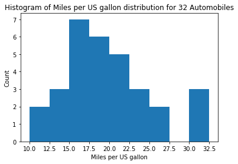

```python
plt.hist(mtcars['mpg'], bins = np.arange(10, 35, 2.5))
plt.title('Histogram of Miles per US gallon distribution for 32 Automobiles')
plt.xticks(np.arange(10, 35, 2.5))
plt.xlabel('Miles per US gallon')
plt.ylabel('Count')
plt.show()
```

### Question 5

Choose two variables in the data and create a scatterplot.

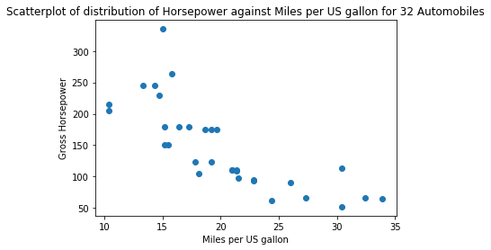

```python
plt.scatter(mtcars['mpg'], mtcars['hp'])
plt.title('Scatterplot of distribution of Horsepower against Miles per US gallon for 32 Automobiles')

plt.xlabel('Miles per US gallon')
plt.ylabel('Gross Horsepower')
plt.show()
```